# Tutorial for using the package `fast-ml`

This package is as good as having a junior Data Scientist working for you. Most of the commonly used EDA steps, Missing Data Imputation techniques, Feature Engineering steps are covered in a ready to use format

## Part 1. EDA for Numerical Variables & Categorical Variables

#### Available functions inside the eda module

#### For Numerical Variable

> - eda_numerical_variable
> - eda_numerical_plots_with_target

#### For Categorical Variable

> - eda_categorical_variable
> - eda_category_plots
> - eda_category_plots_with_target

#### 1. From eda module import function for numerical variable and categorical variable

`from fast_ml.eda import eda_numerical_variable, eda_categorical_variable`

#### 2. Select a variable and run the command for various exploratory analysis

- For Categorical variables use `eda_categorical_variable`
- For Numerical variables use `eda_numerical_variable`

`eda_numerical_variable(df, variable='MSSubClass', model = 'reg', target = 'SalePrice', threshold=10)`

#### 3. To get Category plots for all the variables import function for plotting

`from fast_ml.eda import eda_category_plots, eda_category_plots_with_target`

#### 4. Run the following command to get all the charts

This takes input the list of all the categorical variables you want to plot  
`eda_category_plots(df, variables, add_missing = True, add_rare = False, tol=0.5)`

#### 5. To get Numerical plots for all the variables import function for plotting

`from fast_ml.eda import eda_numerical_plots_with_target`

#### 6. Run the following command to get all the charts

This takes input the list of all the numerical variables you want to plot  
`eda_numerical_plots_with_target(df, variables, target, model = 'clf')`

```python
import pandas as pd
import numpy as np
import matplotlib.pyplot as plt
import seaborn as sns


from fast_ml.eda import eda_numerical_variable, eda_categorical_variable
from fast_ml.eda import eda_category_plots, eda_category_plots_with_target, eda_numerical_plots_with_target

%matplotlib inline

import warnings
warnings.filterwarnings('ignore')
```

```python
df1 = pd.read_csv('../data/titanic.csv')
df1.shape
```

```
(891, 12)
```

```python
df1.head(5)
```

|  | PassengerId | Survived | Pclass | Name | Sex | Age | SibSp | Parch | Ticket | Fare | Cabin | Embarked |
| --- | --- | --- | --- | --- | --- | --- | --- | --- | --- | --- | --- | --- |
| 0 | 1 | 0 | 3 | Braund, Mr. Owen Harris | male | 22.0 | 1 | 0 | A/5 21171 | 7.2500 | NaN | S |
| 1 | 2 | 1 | 1 | Cumings, Mrs. John Bradley (Florence Briggs Th... | female | 38.0 | 1 | 0 | PC 17599 | 71.2833 | C85 | C |
| 2 | 3 | 1 | 3 | Heikkinen, Miss. Laina | female | 26.0 | 0 | 0 | STON/O2. 3101282 | 7.9250 | NaN | S |
| 3 | 4 | 1 | 1 | Futrelle, Mrs. Jacques Heath (Lily May Peel) | female | 35.0 | 1 | 0 | 113803 | 53.1000 | C123 | S |
| 4 | 5 | 0 | 3 | Allen, Mr. William Henry | male | 35.0 | 0 | 0 | 373450 | 8.0500 | NaN | S |

```python
numeric_type = ['float64', 'int64']
category_type = ['object']
```

```python
# All Numerical Variables
df1.select_dtypes(include=numeric_type).columns
```

```
Index(['PassengerId', 'Survived', 'Pclass', 'Age', 'SibSp', 'Parch', 'Fare'], dtype='object')
```

```python
# All Categorical Variables
df1.select_dtypes(include=category_type).columns
```

```
Index(['Name', 'Sex', 'Ticket', 'Cabin', 'Embarked'], dtype='object')
```

## Numerical Variables

```
Total Number of observations :  891

Datatype : float64

Number of distinct values : 88
```

**5 Point Summary :**

```
  Minimum  :		 0.42
  25th Percentile :	 nan
  Median :		 28.0
  75th Percentile :	 nan
  Maximum  :		 80.0
```

**Missing Values :**

```
  Number : 177
  Percentage : 19.865319865319865 %
```

**Variable distribution and Spread statistics :**

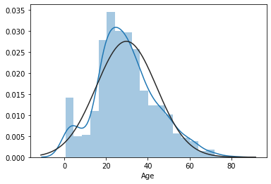

```
Skewness : 0.38910778230082704
Kurtosis : 0.17827415364210353
```

**Normality Check :**

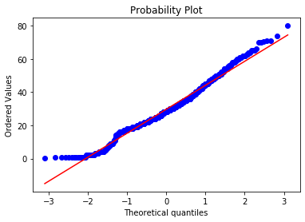

**Box Plot and Visual check for Outlier :**

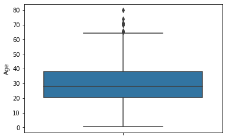

**Outliers (using IQR):**

[output not shown]

**Bivariate plots: Relationship with Target Variable:**

[figure not shown]

**Explore various transformations for Age**

```
1. Logarithmic Transformation
```

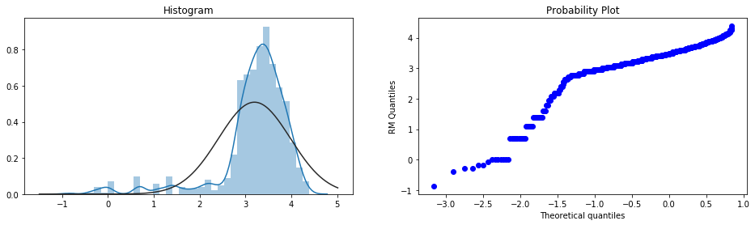

```
2. Exponential Transformation
```

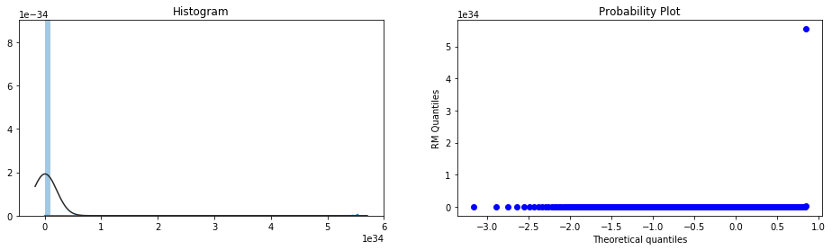

```
3. Square Transformation
```

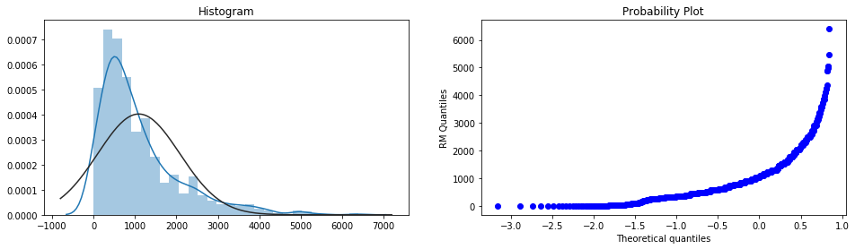

```
4. Square-root Transformation
```

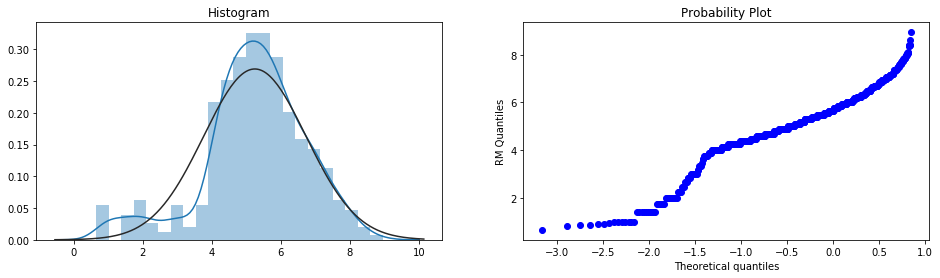

```
5. Box-Cox Transformation
```

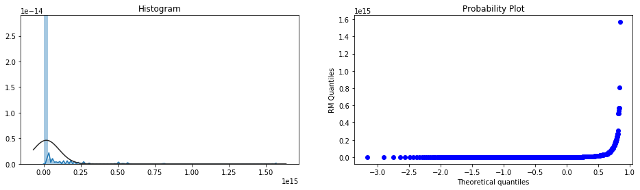

```
Optimal Lambda for Box-Cox transformation is : 8.472135811722177

6. Yeo Johnson Transformation
```

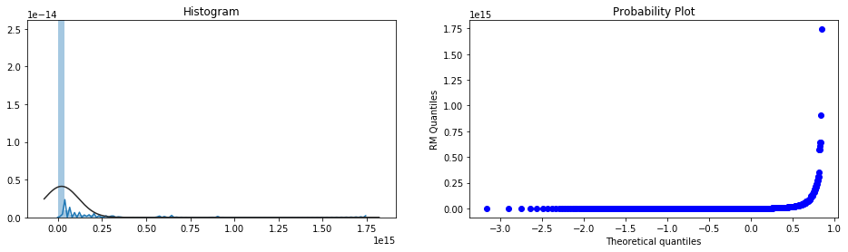

```
Optimal Lambda for Yeo Johnson transformation is : 8.472135811722177
```

```python
# Use the following method for a numerical variable
eda_numerical_variable(df1, variable='Age', model = 'clf', target = 'Survived', threshold=10)
```